# Chapter 7

jim108@gmx.net

5/24/2020

## 7E1.

Want: Three motivating criteria that define information entropy.

Sol.:

1. Continuous function $H(p)$.
2. High number of different states results in a high value of the function. Low number of different states results in a low value.
3. Uncertainty should be additive.

## 7E2.

Given: Coin: Probabilities (heads,tails) $p=(0.7,0.3)$.

Want: $H(p)$.

Sol.:

$H(p) = - E_p \log p = -(0.7\log 0.7 + 0.3\log 0.3) \approx 0.61$.

## 7E3.

Given: 4-sided die: Probabilities $p=(0.2, 0.25, 0.25, 0.3)$.

Want: $H(p)$.

Sol.:

$H(p) = - E_p \log p = -(0.2\log 0.2 + 2*0.25\log 0.25 + 0.3\log 0.3) \approx 1.38$.

## 7E4.

Given: 4-sided die: Probabilities $p=(\frac{1}{3}, \frac{1}{3}, \frac{1}{3}, 0)$.

Want: $H(p)$.

Sol.:

$H(p) = - E_p \log p = -(3*\frac{1}{3}\log \frac{1}{3} + 0) \approx 1.10$.

## 7M1.

Want: Definitions of AIC and WAIC. Which of these criteria is most general? Which assumptions are required to transform the more general criterion into a less general one?

Sol.:

$AIC = D_{train} + 2p = -2lppd + 2p$.

$WAIC = -2 ( lppd - \sum_i var_{\theta}\log p (y_i\mid \theta))$.

$WAIC$ is more general. To use AIC, the following assumptions have to be met:

1. Prios have to be overwelmed by the likelihood.
2. The posterior distribution has to be Gaussian.
3. $N\gg k$.

## 7M2.

Want: Difference between model selection and comparison.

Sol.:

Model comparision does not include: infering causal relationships.

## 7M3.

Given: Comparing models with the information criterion.

Want: Why must all models be fit to exactly the same observations?

Sol.:

```r
set.seed(71)

create_fungus_data <- function(N){
  # simulate initial Rvs
  h0 <- rnorm(N,10,2)

  # assign treatments and simulate fungus and growth
  treatment <- rep( 0:1 , each=N/2 )
  fungus <- rbinom( N , size=1 , prob=0.5 - treatment*0.4 )
  h1 <- h0 + rnorm(N, 5 - 3*fungus)

  # compose a clean data frame
  d <- data.frame( h0=h0 , h1=h1 , treatment=treatment , fungus=fungus )
  return(d)
}

fungus_model_list <- alist(
        h1 ~ dnorm( mu , sigma ),
        mu <- h0 * p,
        p <- a + bt*treatment,
        a ~ dlnorm( 0 , 0.2 ),
        bt ~ dnorm( 0 , 0.5 ),
        sigma ~ dexp( 1 )
    )

create_waic <- function(N){
  dN <- create_fungus_data(N)
  mN <- quap(fungus_model_list, data=dN )
  return(WAIC(mN))
}

N_seq <- seq( from=10 , to=50 , length.out=5 )

waics <- sapply(N_seq, create_waic)
waics
```

```
##         [,1]      [,2]      [,3]      [,4]      [,5]
## WAIC    49.24759  89.9468   131.0573  158.5499  208.9496
## lppd    -19.55548 -41.45005 -60.45909 -76.01595 -101.9077
## penalty 5.068321  3.523344  5.069575  3.258977  2.567117
## std_err 6.978381  6.122201  12.39324  9.984725  7.763744
```

- WAIC/ lppd increases with the number of observations.

## 7M4.

Given: Comparing models with PSIS or WAIC.

Want: What happens to the effective number of parameters as a prior becomes more concentrated? Why?

Sol.:

```r
d <- create_fungus_data(100)


fungus_model_list <- alist(
        h1 ~ dnorm( mu , sigma ),
        mu <- h0 * p,
        p <- a + bt*treatment,
        a ~ dlnorm( 0 , 0.2 ),
        bt ~ dnorm( 0 , b_var ),
        sigma ~ dexp( 1 )
    )

N <- 100
d <- create_fungus_data(N)

d$b_var <- 0.1
m0.1 <- quap(fungus_model_list, data=d )

d$b_var <- 0.5
m0.5 <- quap(fungus_model_list, data=d )


d$b_var <- 1
m1 <- quap(fungus_model_list, data=d )

compare(m0.1,m0.5,m1)
```

```
##          WAIC       SE      dWAIC      dSE    pWAIC    weight
## m1   418.8672 12.04553 0.00000000       NA 2.637093 0.4114565
## m0.5 418.9002 12.08376 0.03292038 1.085853 2.466109 0.4047393
## m0.1 420.4789 12.03267 1.61166540 3.455224 1.826399 0.1838041
```

- The effective number of parameters decrease if the prior gets more concentrated.
- The more concentrated the prior the more simpler the functions the less parameters.

## 7M5.

Want: Why informative priors reduce overfitting?

Sol.:

They exclude unrealistic/ extreme values, therefore reducing the function pool.

## 7M6.

Want: Why overly informative priors result in underfitting.

Sol.:

The function pool is reduced to a degree that the pattern to fit cannot expressed by a function from it.

## 7H1.

```r
data("Laffer")
d<- Laffer
head(d)
```

```
##   tax_rate tax_revenue
## 1     0.07       -0.06
## 2     8.81        2.45
## 3    12.84        3.58
## 4    16.24        2.19
## 5    19.18        2.46
## 6    19.29        1.95
```

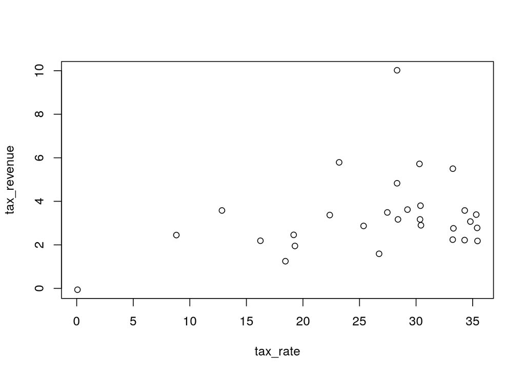

```r
plot(tax_revenue ~ tax_rate, d)
```

```r
d$Rv <- standardize(d$tax_revenue)
d$Ra <- standardize(d$tax_rate)

tax_rate_bar <- mean(d$tax_rate)

m7H1_l <- quap(
    alist(
        Rv ~ dnorm( mu , sigma ) ,
        mu <- a + b*Ra,
        a ~ dlnorm( 0 , 1 ) ,
        b ~ dnorm( 0 , 0.5 ) ,
        sigma ~ dexp( 1 )
    ) , data = d )

precis( m7H1_l )
```

```
##            mean         sd        5.5%     94.5%
## a     0.1585067 0.09760264 0.002518789 0.3144945
## b     0.2845639 0.16604681 0.019189072 0.5499388
## sigma 0.9302535 0.12050574 0.737662046 1.1228449
```

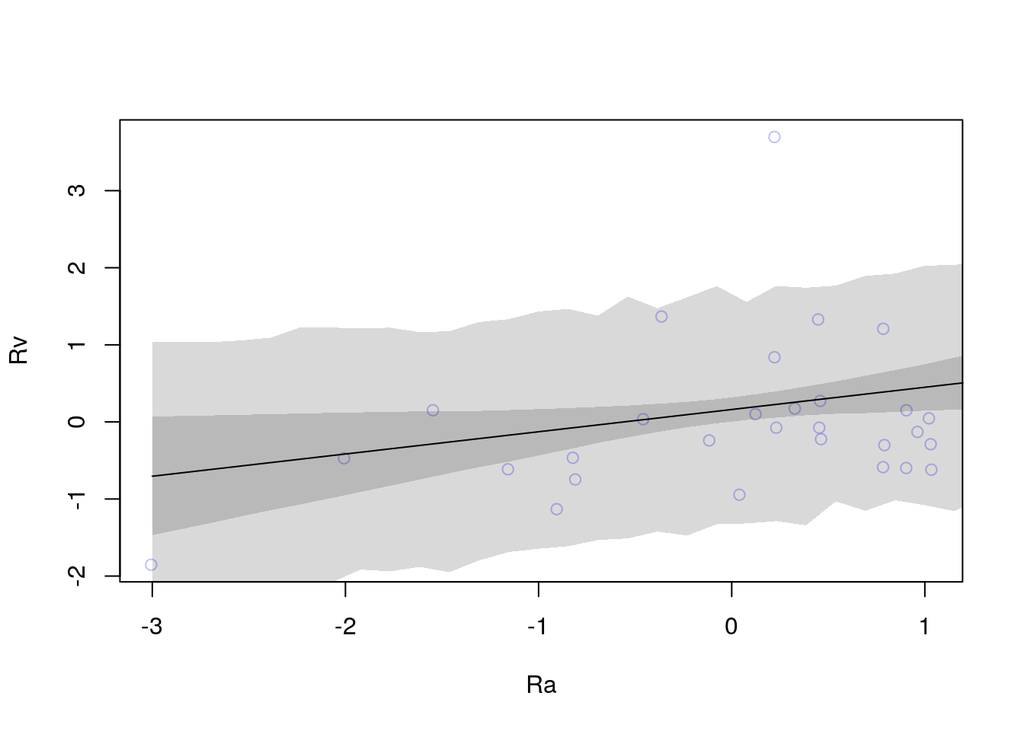

```r
Ra.seq <- seq( from=-3, to=3, length.out = 40)
pred_dat <- list(Ra=Ra.seq)
mu <- link(m7H1_l, data=pred_dat)
mu.mean <- apply( mu, 2, mean)
mu.PI <- apply( mu, 2, PI, prob=0.89)
sim.Rv <- sim(m7H1_l, data=pred_dat)
Rv.PI <- apply( sim.Rv, 2, PI, prob=0.89)


plot(Rv ~ Ra, d, col=col.alpha(rangi2,0.5))
lines( Ra.seq, mu.mean)
shade( mu.PI, Ra.seq)
shade( Rv.PI, Ra.seq)
```

```r
d$Ra_2 <- d$tax_rate^2

m7H1_2 <- quap(
    alist(
        Rv ~ dnorm( mu , sigma ) ,
        mu <- a + b1*Ra + b2*Ra_2 ,
        a ~ dnorm( 0 , 1 ) ,
        b1 ~ dlnorm( 0 , 0.5 ) ,
        b2 ~ dnorm( 0 , 0.5 ) ,
        sigma ~ dexp( 1 )
    ) , data=d )

precis( m7H1_2 )
```

```
##               mean           sd         5.5%        94.5%
## a      0.877342143 0.6009737371 -0.083129961 1.837814e+00
## b1     0.753408497 0.2796124637  0.306533775 1.200283e+00
## b2    -0.001170528 0.0007707332 -0.002402309 6.125236e-05
## sigma  0.889950101 0.1151496833  0.705918667 1.073982e+00
```

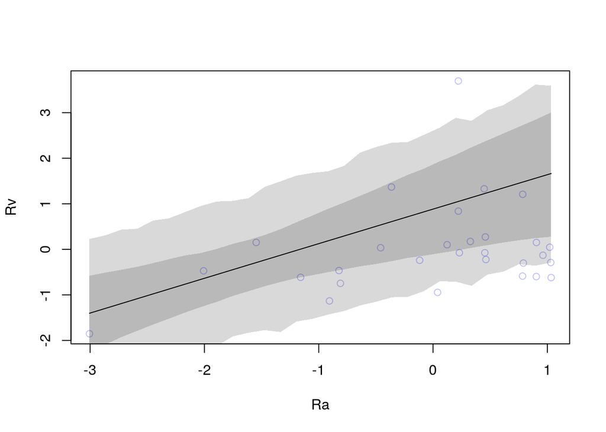

```r
Ra.seq <- seq( from=min(d$Ra) , to=max(d$Ra) , length.out=30 )
pred_dat <- list( Ra=Ra.seq , Ra_2=Ra.seq^2 )
mu <- link( m7H1_2 , data=pred_dat )
mu.mean <- apply( mu , 2 , mean )
mu.PI <- apply( mu , 2 , PI , prob=0.89 )
sim.Rv <- sim( m7H1_2 , data=pred_dat )
Rv.PI <- apply( sim.Rv , 2 , PI , prob=0.89 )

plot( Rv ~ Ra , d , col=col.alpha(rangi2,0.5) )
lines( Ra.seq , mu.mean )
shade( mu.PI , Ra.seq )
shade( Rv.PI , Ra.seq )
```

```r
compare(m7H1_l, m7H1_2)
```

```
##            WAIC       SE     dWAIC      dSE    pWAIC    weight
## m7H1_l 89.52288 20.45726 0.0000000       NA 5.890604 0.5317459
## m7H1_2 89.77719 24.99539 0.2543097 5.298184 7.282455 0.4682541
```

- The curved model does not use the squared parameter, but it has a higher intercept and a higher slope.
- The WAIC between both models is almost identical.
- The tax revenue increase with the tax rate.

## 7H2.

Given:

Sol.:

```r
set.seed(24071847)
PSIS_m7H2 <- PSIS(m7H1_2,pointwise=TRUE)
```

```
## Some Pareto k values are very high (>1). Set pointwise=TRUE to inspect individual points.
```

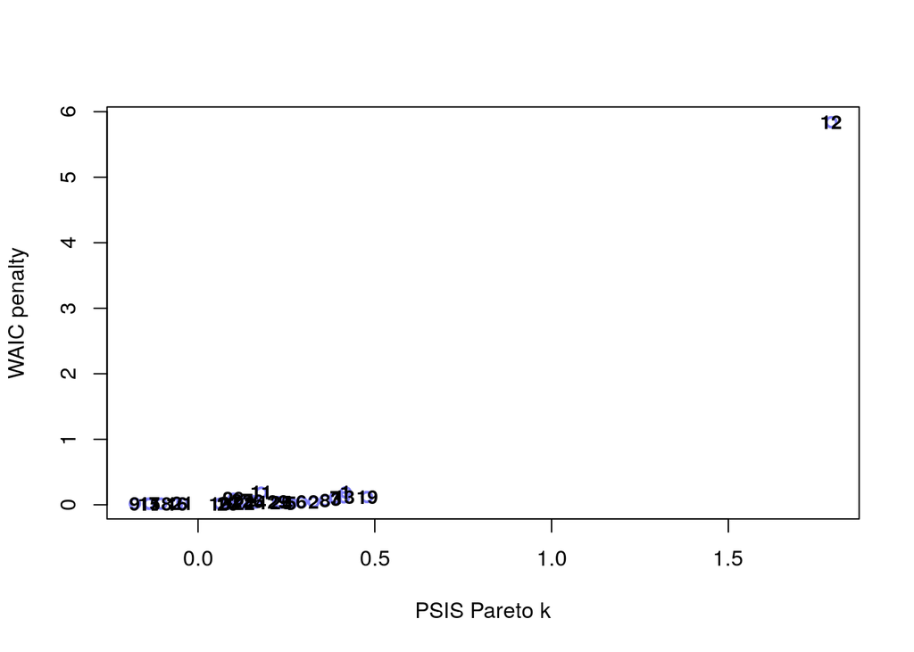

```r
set.seed(24071847)
WAIC_m7H2 <- WAIC(m7H1_2,pointwise=TRUE)
plot( PSIS_m7H2$k , WAIC_m7H2$penalty , xlab="PSIS Pareto k" ,
    ylab="WAIC penalty" , col=rangi2 , lwd=2 )
text(WAIC_m7H2$penalty ~ PSIS_m7H2$k , labels=rownames(d),data=d, cex=0.9, font=2)
```

```r
m7H1_2t <- quap(
    alist(
        Rv ~ dstudent( 2, mu , sigma ) ,
        mu <- a + b1*Ra + b2*Ra_2 ,
        a ~ dnorm( 0 , 1 ) ,
        b1 ~ dlnorm( 0 , 0.5 ) ,
        b2 ~ dnorm( 0 , 0.5 ) ,
        sigma ~ dexp( 1 )
    ) , data=d )

precis( m7H1_2t )
```

```
##               mean           sd         5.5%        94.5%
## a      1.092147442 0.1545315784  0.845176134  1.339118751
## b1     0.896476466 0.1037167538  0.730717062  1.062235871
## b2    -0.001682284 0.0002848768 -0.002137572 -0.001226996
## sigma  0.445748971 0.1031002230  0.280974902  0.610523040
```

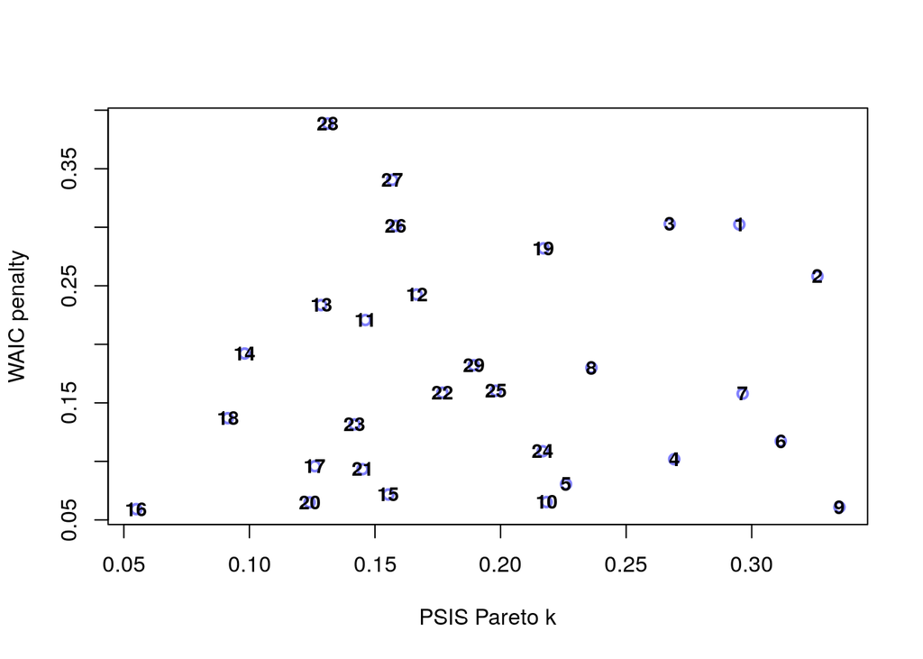

```r
set.seed(24071847)
PSIS_m7H2t <- PSIS(m7H1_2t,pointwise=TRUE)
set.seed(24071847)
WAIC_m7H2t <- WAIC(m7H1_2t,pointwise=TRUE)
plot( PSIS_m7H2t$k , WAIC_m7H2t$penalty , xlab="PSIS Pareto k" ,
    ylab="WAIC penalty" , col=rangi2 , lwd=2 )
text(WAIC_m7H2t$penalty ~ PSIS_m7H2t$k , labels=rownames(d),data=d, cex=0.9, font=2)
```

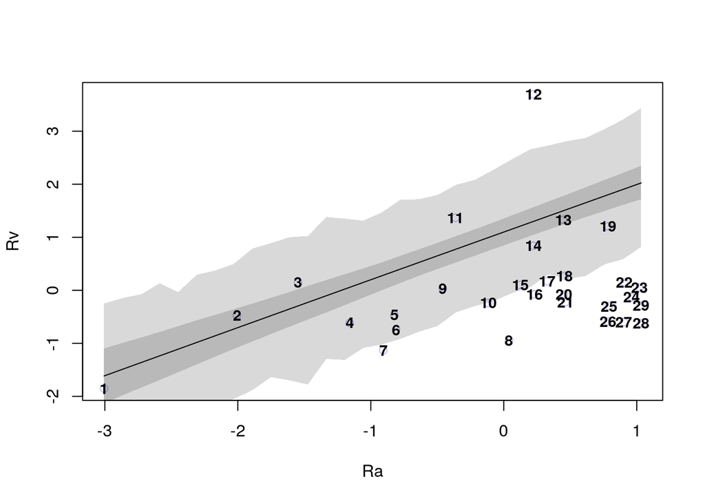

```r
Ra.seq <- seq( from=min(d$Ra) , to=max(d$Ra) , length.out=30 )
pred_dat <- list( Ra=Ra.seq , Ra_2=Ra.seq^2 )
mu <- link( m7H1_2t , data=pred_dat )
mu.mean <- apply( mu , 2 , mean )
mu.PI <- apply( mu , 2 , PI , prob=0.89 )
sim.Rv <- sim( m7H1_2t , data=pred_dat )
Rv.PI <- apply( sim.Rv , 2 , PI , prob=0.89 )

plot( Rv ~ Ra , d , col=col.alpha(rangi2,0.5) )
lines( Ra.seq , mu.mean )
shade( mu.PI , Ra.seq )
shade( Rv.PI , Ra.seq )
text(Rv ~ Ra, labels=rownames(d),data=d, cex=0.9, font=2)
```

- The robust regression with the Student’s t distribution changed the regression line very much towards the outlier point (12). Now, around half of the values are not part of the 89 % interval of a Gaussian distribution anymore.

## 7H3.

Given:

```r
birds <- data.frame("Species_A" = c(0.2,0.8,0.05),
                    "Species_B" = c(0.2,0.1,0.15),
                    "Species_C" = c(0.2,0.05,0.7),
                    "Species_D" = c(0.2,0.025,0.05),
                    "Species_E" = c(0.2,0.025,0.05))
row.names(birds) <- c("Island_1","Island_2","Island_3")
birds
```

```
##          Species_A Species_B Species_C Species_D Species_E
## Island_1      0.20      0.20      0.20     0.200     0.200
## Island_2      0.80      0.10      0.05     0.025     0.025
## Island_3      0.05      0.15      0.70     0.050     0.050
```

Want: Entropy.

Sol.:

```r
d <- birds
entropy <- function(p) -sum(p*log(p))
row.sums <- apply(d, 1,  entropy)
row.sums
```

```
##  Island_1  Island_2  Island_3
## 1.6094379 0.7430039 0.9836003
```

Want: Use each island’s bird distribution to predict the other two. This means to compute the K-L Divergence of each island from the others, treating each island as if it were a statistical model of the other islands. You should end up with 6 different K-L Divergence values. Which island predicts the others best? Why?

```r
d <- birds

D_KL <- function(p,q) sum(p*(log(p/q)))
d_12 <- D_KL(d[1,], d[2,])
d_13 <- D_KL(d[1,], d[3,])
d_21 <- D_KL(d[2,], d[1,])
d_23 <- D_KL(d[2,], d[3,])
d_31 <- D_KL(d[3,], d[1,])
d_32 <- D_KL(d[3,], d[2,])
d_mat <- matrix(c(0, d_12,d_13,d_21,0,d_23,d_31,d_32,0), nrow = 3, ncol = 3)
d_mat
```

```
##           [,1]     [,2]      [,3]
## [1,] 0.0000000 0.866434 0.6258376
## [2,] 0.9704061 0.000000 1.8388452
## [3,] 0.6387604 2.010914 0.0000000
```

- Island 1 predicts the others best.
- Island 1 has the highest entropy.
- It has the highest entropy because the probabilities are uniform distributed across the species.

## 7H4.

Given: Happiness simulation.

```r
d <- sim_happiness( seed=1977 , N_years=1000 )
unmarried_happiness <- mean(d[which(d$married==0),]$happiness)
married_happiness <- mean(d[which(d$married==1),]$happiness)
unmarried_happiness
```

```
## [1] -0.3468242
```

```r
married_happiness
```

```
## [1] 0.8062996
```

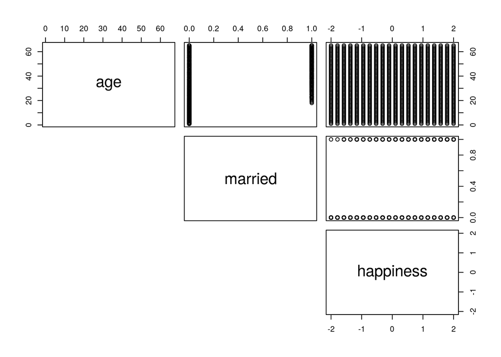

```r
pairs(d, lower.panel=NULL)
```

```r
## R code 6.22
d2 <- d[ d$age>17 , ] # only adults
d2$A <- ( d2$age - 18 ) / ( 65 - 18 )

## R code 6.23
d2$mid <- d2$married + 1
m6.9 <- quap(
    alist(
        happiness ~ dnorm( mu , sigma ),
        mu <- a[mid] + bA*A,
        a[mid] ~ dnorm( 0 , 1 ),
        bA ~ dnorm( 0 , 2 ),
        sigma ~ dexp(1)
    ) , data=d2 )
precis(m6.9,depth=2)
```

```
##             mean         sd       5.5%      94.5%
## a[1]  -0.2350877 0.06348986 -0.3365568 -0.1336186
## a[2]   1.2585517 0.08495989  1.1227694  1.3943340
## bA    -0.7490274 0.11320112 -0.9299447 -0.5681102
## sigma  0.9897080 0.02255800  0.9536559  1.0257600
```

```r
## R code 6.24
m6.10 <- quap(
    alist(
        happiness ~ dnorm( mu , sigma ),
        mu <- a + bA*A,
        a ~ dnorm( 0 , 1 ),
        bA ~ dnorm( 0 , 2 ),
        sigma ~ dexp(1)
    ) , data=d2 )
precis(m6.10)
```

```
##                mean         sd       5.5%     94.5%
## a      1.649248e-07 0.07675015 -0.1226614 0.1226617
## bA    -2.728620e-07 0.13225976 -0.2113769 0.2113764
## sigma  1.213188e+00 0.02766080  1.1689803 1.2573949
```

Want: Compare these two models using WAIC (or LOO, they will produce identical results). Which model is expected to make better predictions? Which model provides the correct causal inference about the influence of age on happiness? Can you explain why the answers to these two questions disagree?

Sol.:

- Intercept and slope are 0 at m6.10. It is a very simple model for 3 variables. That’s suspicious, I guess it should make worse pedictions unless the variables are independent.

```r
compare(m6.9, m6.10)
```

```
##           WAIC       SE    dWAIC      dSE    pWAIC       weight
## m6.9  2713.971 37.54465   0.0000       NA 3.738532 1.000000e+00
## m6.10 3101.906 27.74379 387.9347 35.40032 2.340445 5.768312e-85
```

- m6.9 has the best WAIC value.
- The standard error of dWAIC (difference to the best model’s WAIC) is about 10 times smaller than the actual difference to the best model’s WAIC (dSE < dWAIC) for m6.10 to m6.9.
- Thus, m6.9 is significatly better than m6.10 according to WAIC.
- m6.10 answers the question of “influence of age on happiness?”.
- Conditioned on marriage m6.9 makes better predictions than m6.10, but it does not adhere to the actual question.

## 7H5.

Given: Foxes data.

Want: Compare

1. avgfood(F) + groupsize(G) + area(T)
2. avgfood(F) + groupsize(G)
3. groupsize(G) + area(T)
4. area(T)

Sol.:

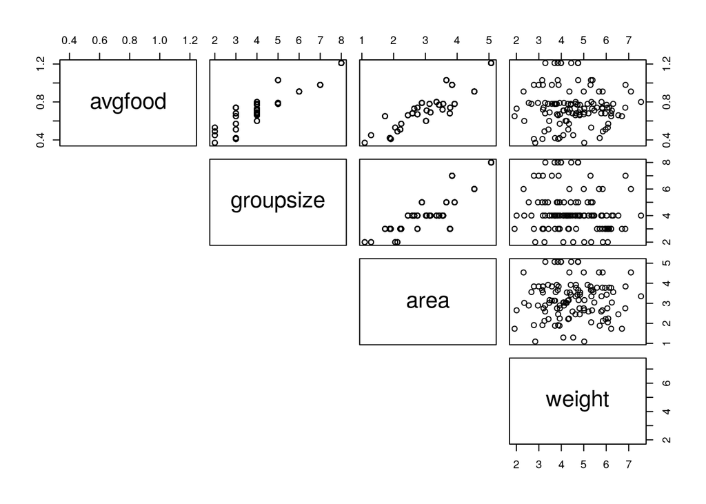

```r
data("foxes")
d <- foxes
pairs(d[,c("avgfood","groupsize","area", "weight")], lower.panel=NULL)
```

```r
head(d)
```

```
##   group avgfood groupsize area weight
## 1     1    0.37         2 1.09   5.02
## 2     1    0.37         2 1.09   2.84
## 3     2    0.53         2 2.05   5.33
## 4     2    0.53         2 2.05   6.07
## 5     3    0.49         2 2.12   5.85
## 6     3    0.49         2 2.12   3.25
```

```r
d$F <- standardize( d$avgfood )
d$W <- standardize( d$weight )
d$G <- standardize( d$groupsize )
d$T <- standardize( d$area )


mFGT <- quap(
    alist(
        W ~ dnorm( mu , sigma ) ,
        mu <- a + bF*F + bG*G + bT*T,
        c(a,bF,bG,bT) ~ dnorm( 0 , 0.5 ) ,
        sigma ~ dexp( 1 )
    ) , data = d )

mFG <- quap(
    alist(
        W ~ dnorm( mu , sigma ) ,
        mu <- a + bF*F + bG*G ,
        c(a,bF,bG) ~ dnorm( 0 , 0.5 ) ,
        sigma ~ dexp( 1 )
    ) , data = d )

mGT <- quap(
    alist(
        W ~ dnorm( mu , sigma ) ,
        mu <- a + bG*G + bT*T,
        c(a,bG,bT) ~ dnorm( 0 , 0.5 ) ,
        sigma ~ dexp( 1 )
    ) , data = d )

mF <- quap(
    alist(
        W ~ dnorm( mu , sigma ) ,
        mu <- a + bF*F ,
        c(a,bF) ~ dnorm( 0 , 0.5 ) ,
        sigma ~ dexp( 1 )
    ) , data = d )

mT <- quap(
    alist(
        W ~ dnorm( mu , sigma ) ,
        mu <- a + bT*T ,
        c(a,bT) ~ dnorm( 0 , 0.5 ) ,
        sigma ~ dexp( 1 )
    ) , data = d )

compare(mFGT,mFG,mGT,mF,mT)
```

```
##          WAIC       SE     dWAIC      dSE    pWAIC      weight
## mFGT 323.1599 16.29671  0.000000       NA 4.792986 0.463482206
## mGT  324.1801 15.70167  1.020166 2.902071 3.857939 0.278295866
## mFG  324.3638 16.14017  1.203924 3.598184 3.961315 0.253865866
## mF   333.7436 13.80792 10.583656 7.200937 2.575864 0.002332499
## mT   334.0277 13.81197 10.867817 7.250087 2.802232 0.002023563
```

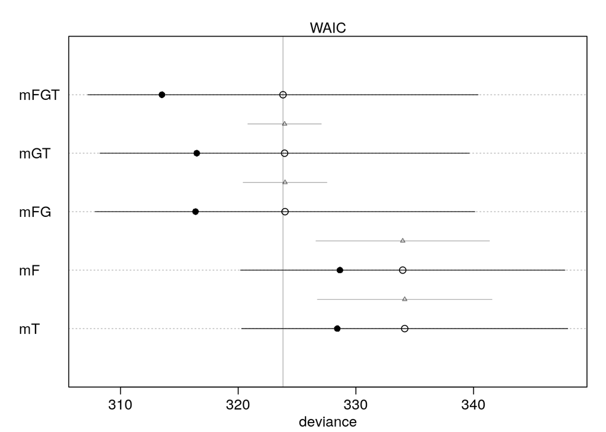

```r
plot(compare(mFGT,mFG,mGT,mF,mT))
```

- F, G, T are all positively correlated according to the pairs plot.
- mFGT makes the best predictions according to WAIC.
- The standard error of dWAIC (difference to the best model’s WAIC) is greater than the actual difference to the best model’s WAIC (dSE > dWAIC) for mGT and mFG.
- The standard error of dWAIC (difference to the best model’s WAIC) is smaller than the actual difference to the best model’s WAIC (dSE < dWAIC) for mF and mT.
- Thus, the differences between 2 or 3 perdictor variables are small.
- Thus, the differences between 2 or 3 and 1 perdictor variables is relatively big.

## Rethinking package/RStudio issues

- `plot(compare(..))` shows the pairs plot inside RStudio but the indented lines plot after html conversion. (https://github.com/rmcelreath/rethinking/issues/22)
- The precis plot can be fixed by `precis_plot(precis(...))`.
- Reinstalling did not solve the issue.